# Projet 6 : Détection de faux billets

Import des données :

```r
billets = read.csv2('1.donnees/billets.csv', sep=',', dec = '.')
```

# Préparation des données

- On renomme les modalités de la variable `is_guenine` en deux modalités `vrai_billet` & `faux_billet`

# Statistiques déscriptives

## Mission 0 : Analyses univariées et bivariées

### Déscription du dataframe

- le dataset contient **170** lignes & **7 colonnes**
- Il y a **70 faux billets** et **100 vrais billets**

Exemple d’un billet :

```
##    is_genuine length height_left height_right margin_low margin_up
## 1 vrai_billet 171.81      104.86       104.95       4.52      2.89
##   diagonal
## 1   112.83
```

### Univariées

Quelques statistiques univariées :

```
## Description of billets[, billet.var.dim]
```

```
##
##  Numeric
##                mean   sd
## length       171.94 0.31
## height_left  104.07 0.30
## height_right 103.93 0.33
## margin_low     4.61 0.70
## margin_up      3.17 0.24
## diagonal     112.57 0.92
```

**On a des données très précises** :

### Bivariées

#### Corrélation entre les variables

Matrice de corrélation linéaire :

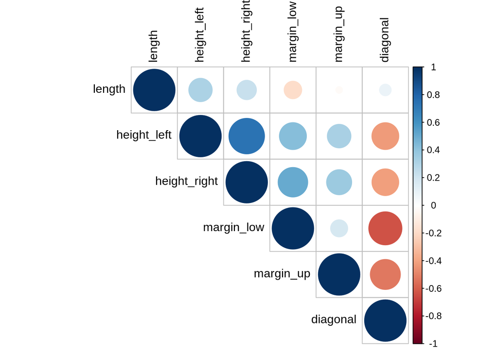

On constate les corrélations suivantes :

- corrélation négative entre `margin_low` et `diagonal`
- corrélation positive entre `height_left` et `height_right`
- corrélation négative entre `margin_up` et `diagonal` ?

#### Comparaison de la distribution des billets vrai et faux

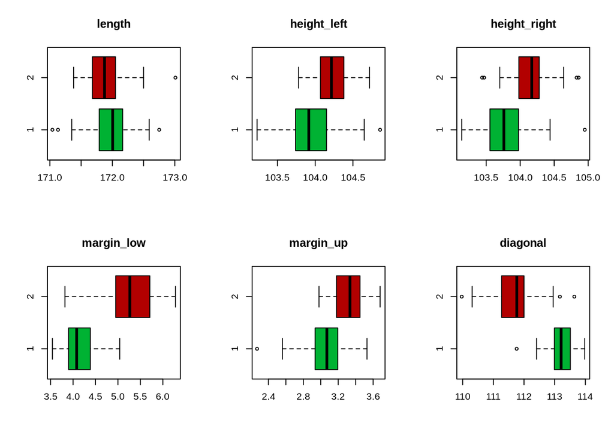

```r
par(mfrow=c(2,3))
for (var in billet.var.dim) {
  boxplot(
    billets[billets$is_genuine == 'vrai_billet', var],
    billets[billets$is_genuine == 'faux_billet', var],
    col = c('#00B233', '#B20000'),
    horizontal = TRUE
  )
  title(main=var)
}
```

Variables qui semblent les plus discriminantes :

- `margin_low`
- `diagonal`
- `margin_up` ?

## Mission 1 : Analyse en Composante Principale

### Éboulis des valeurs propres

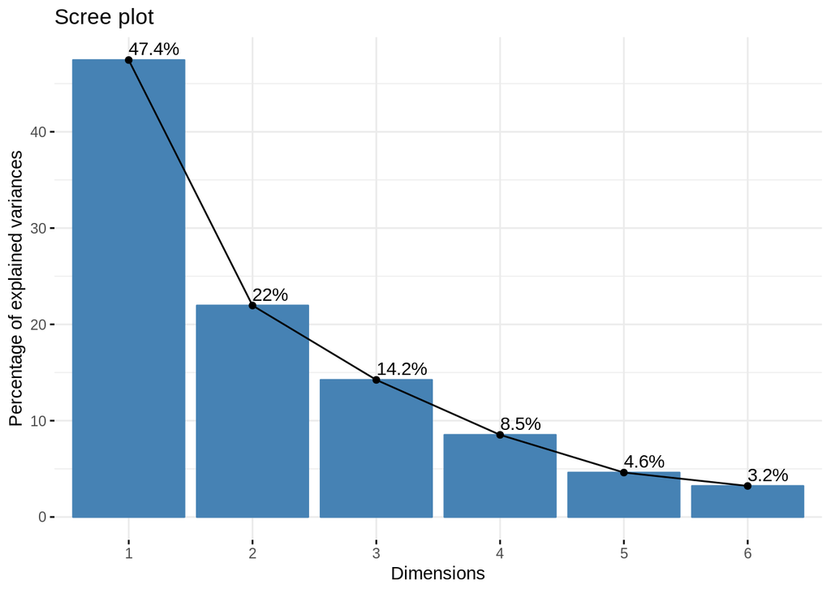

** On peut aussi afficher la répartition du cos2 sur les dimensions : **

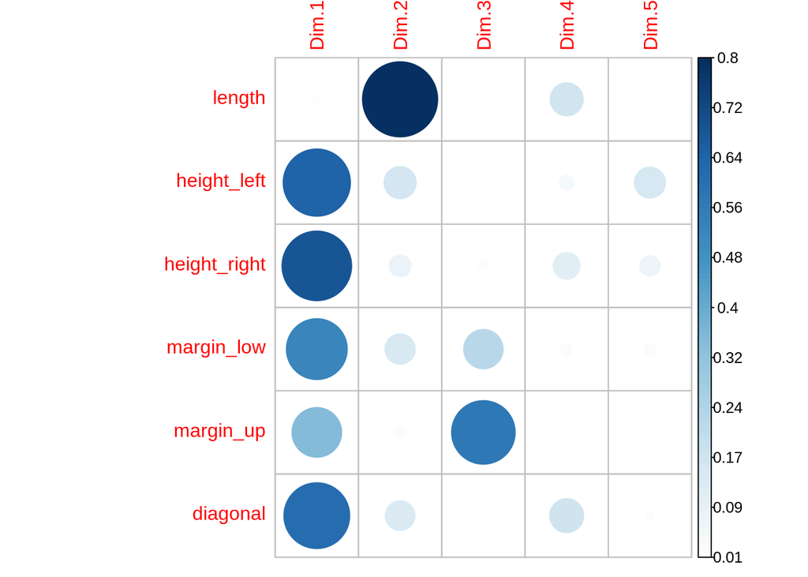

On constate que la majorité des variables sont bien représentées sur PC1 sauf `length`, qui est exclusivement corrélée à PC2. il en est de même avec `margin_up` et PC3.

### Cercle des corrélations

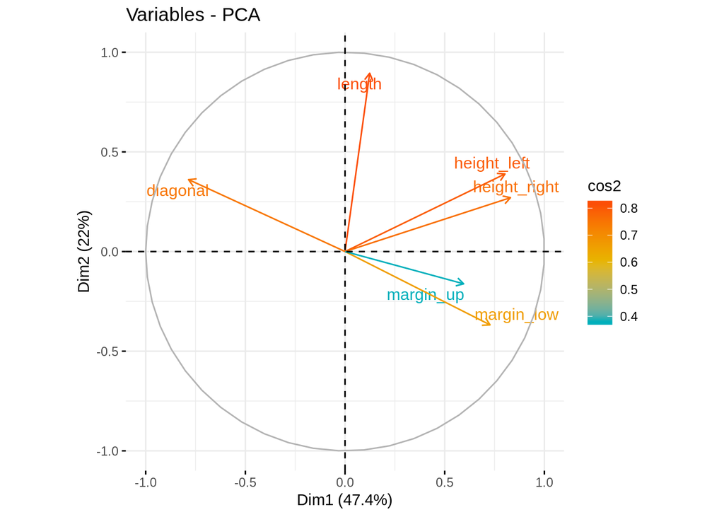

**PC1**

- variables liées aux hauteurs et aux marges
- la diagonal est plutôt corrélées négativement à PC1 (ce qui n’est pas très logique)

**PC2** : quasi-exclusivement expliquée par length

### Nuage des individus

On observe les nuages sur les 3 premiers plans factoriels :

#### Plan 1-2

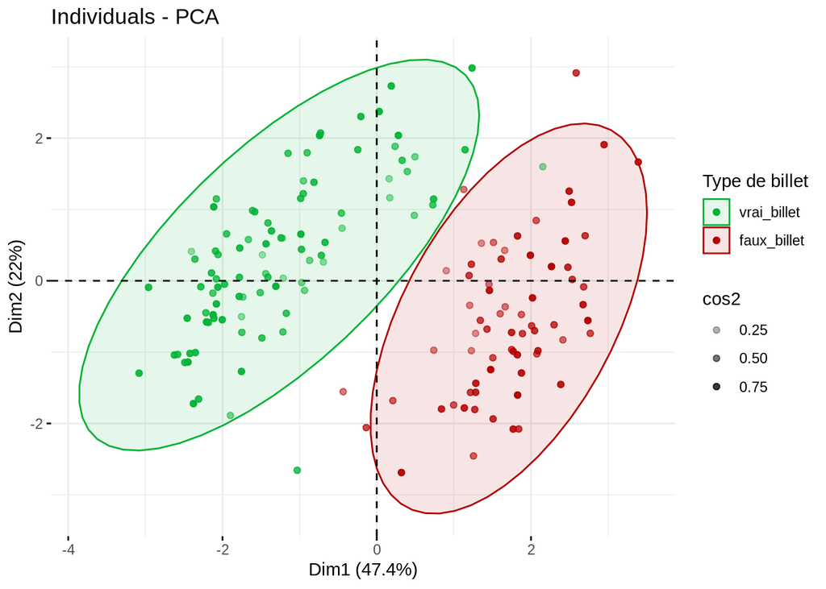

Contient ~70% de l’information.

La qualité de la répresentation est représenté par le niveau de transparence du point. On n’affiche ici que les billets dont le `cos2 > 0.3`

On observe très distinctement les deux groupes : **les dimensions sont de très bon indicateurs** pour estimer si un billet est vrai ou faux.

#### Plan 1-3

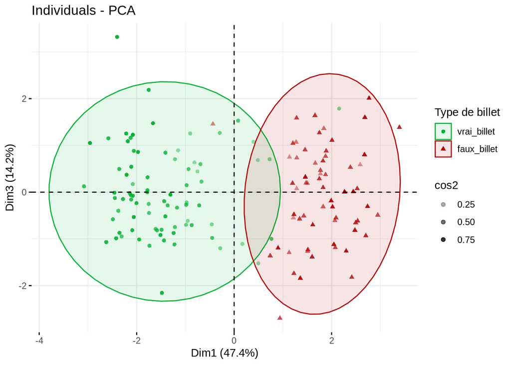

Contient ~60% de l’information

Les vrais et les faux billets se confondent plus que sur PF1.

#### Plan 2-3

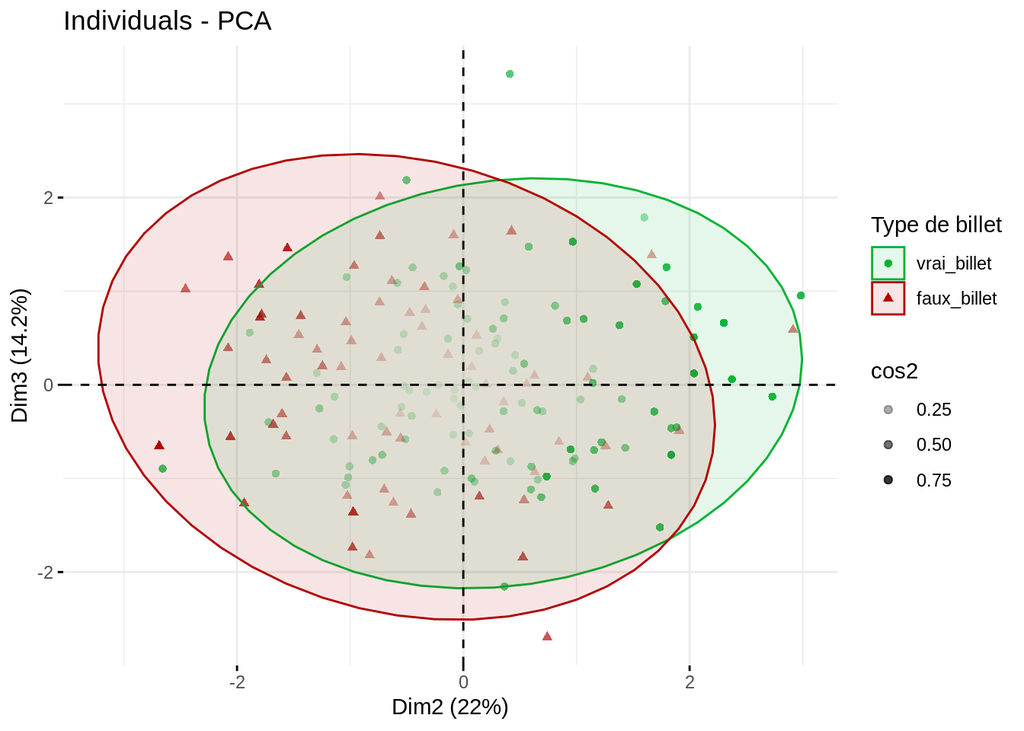

Contient (seulement) 36% de l’information.

Beaucoup de points transparents : la **projection est mauvaise**

Les vrais et les faux billets ont des positions presques analogues.

#### Conclusion

Pour illsutrer les résultats des futurs alogrithmes, on choisit PF1, car il offre la rerprésentation la plus séparée des vrai et faux billets.

# Maching Learning

Dans cette partie on va effectuer différents algorithmes de machine learning supervisés et non-supervisés :

- Clustering Ascendant Hiérarchique
- K-means
- HCPC
- Régression logistique

## Mission 2 : Classification non supervisée

Clustering Ascendant Hiérarchique et K-means

### Préparation des données

- **On normalise les données quantitatives des billets**

### Clustering Ascendant Hiérarchique

#### Calculs

```r
cah.result = hclust(dist(pop.non.sprv.appr))

# découpage en 2 classes
cah.clusters = cutree(cah.result, 2)
```

#### Matrice de confusion

```
##
## cah.clusters vrai_billet faux_billet
##            1          24          69
##            2          76           1
```

On constate que :

- la majorité des vrai billets sont dans le cluster 2
- la majorité des faux billets sont dans le cluster 1

Remarque : il y a beaucoup de vrai billets qui sont considérés comme faux (*faux négatif*). C’est beaucoup, mais on préfère cela à l’inverse (*faux positif : faux billets qui sont considérés comme vrai*)

**85% des billets sont bien classés**.

#### Visualisation sur le 1er plan factoriel

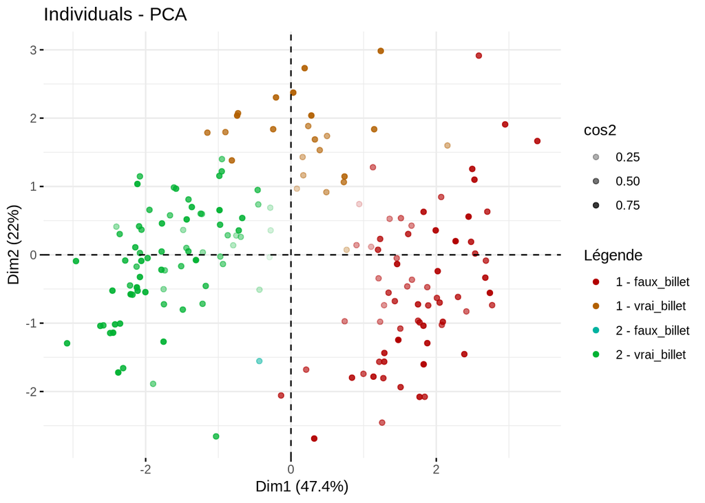

On voit ici les faux négatifs en orange

### K-means

#### Calcul

```r
set.seed(1027)
kmeans.result = kmeans(x = pop.non.sprv.appr, 2)
kmeans.clusters = kmeans.result$cluster
```

#### matrice de confusion

```
##
## kmeans.clusters vrai_billet faux_billet
##               1          92           1
##               2           8          69
```

On constate que la majorité :

- des faux billets sont dans le cluster 2
- des vrais billets sont dans le cluster 1

**95% des billets sont bien classés**.

#### Visualisation sur le 1er plan factoriel

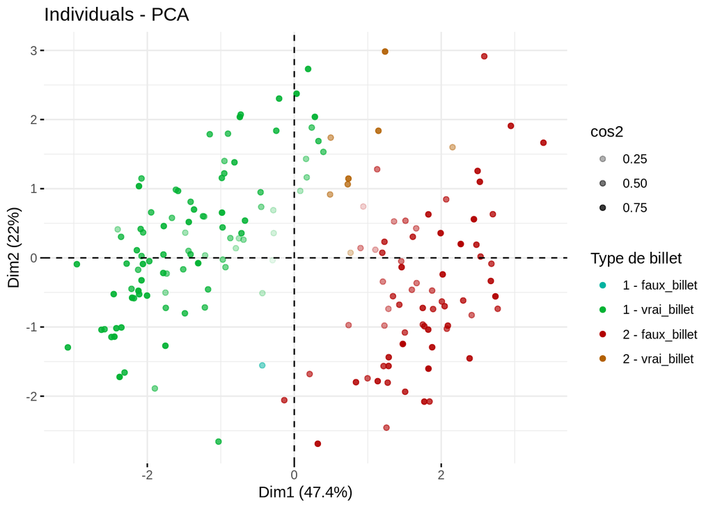

On constate que le nombre de faux négatif a baissé à 8 (il y a moins de points oranges).

### HCPC

La méthode HCPC combine l’ACP, le CAH et les k-means.

#### Calcul

```r
res.hcpc <- HCPC(acp.result, nb.clust = 2, graph = FALSE)
hcpc.clusters = res.hcpc$data.clust$clust
```

#### Matrice de confusion

```
##
## hcpc.clusters vrai_billet faux_billet
##             1          92           1
##             2           8          69
```

On a les même résultats qu’avec l’alogrithme `k-means`

## Mission 3 : Classification supervisées

### Préparation des données

On divise en un jeu d’apprentissage et de test en **75%-25%**.

On utilise la librairie `caret` pour avoir une proportion similaire de vrai/faux billets dans chaque jeu.

*Effectif du jeu d’apprentissage :*

```
##
## vrai_billet faux_billet
##          75          53
```

*Effectif du jeu de test :*

```
##
## faux_billet vrai_billet
##          17          25
```

### Régression logistique

On va construire un **modèle basée sur la régression logistique**, pour **calculer la probabilité d’un billet** qu’il soit dans l’une ou l’autre des modalités de `is_genuine` en fonction de ses dimensions.

#### Calcul du modèle avec l’approche *stepwise*

l’approche stepwise va proposer un choix de variables expliquatives optimales. en minimisant **l’AIC**.

Voici les variables choisies et leurs coefficients :

```
## (Intercept)    diagonal  margin_low   margin_up
##  3247.43065   -36.58252    63.59826   174.72409
```

#### Prédiciton du jeu de test

```r
pop.sprv.test.prediction = ifelse(
  predict(reg.log.model, pop.sprv.test.explicatives, type='response') < 0.5,
  'vrai_billet',
  'faux_billet')
```

#### Evaluation du modèle

##### Matrice de confusion

```
##              is_guenine
## prediction    vrai_billet faux_billet
##   faux_billet           1          15
##   vrai_billet          24           2
```

**La précision vaut 0.92** et **le rappel vaut 0.96**

Mais ces résultats ne sont pas précis car notre échantillon ne contient que 42 individus.

#### Projection sur 1er plan factoriel

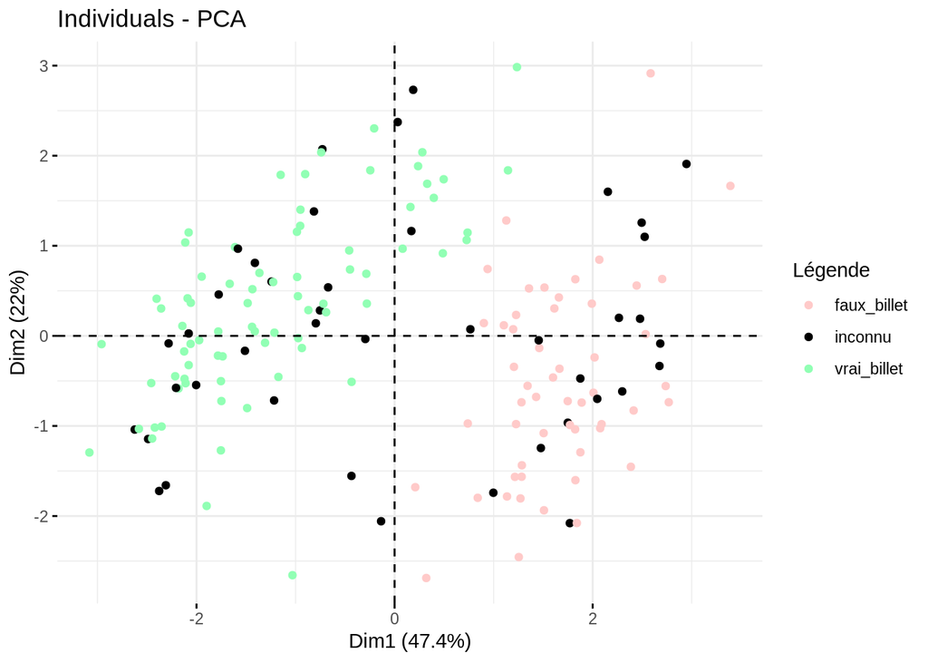

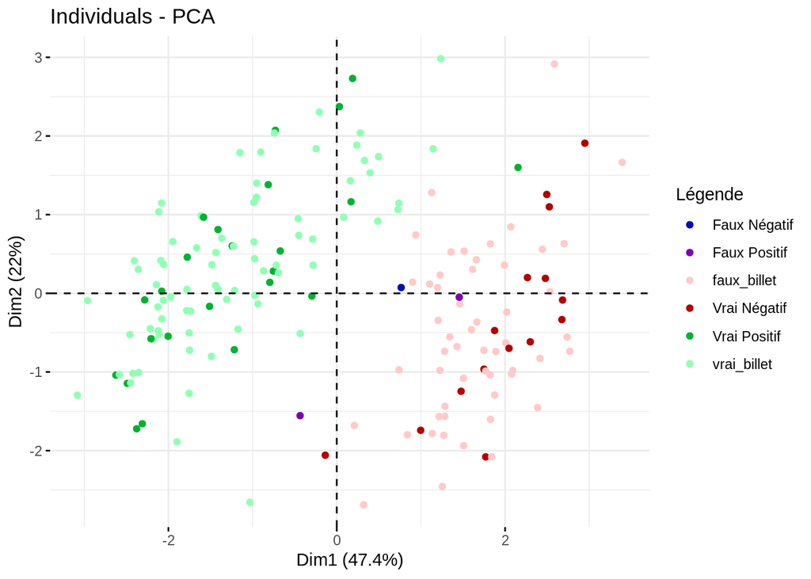